# Riparian Invertebrates: Investigate Methods - v.2

## Field data

Import previously prepared field data. This comprises a series of sampling events collated by Jon Webb.

Here are 10 random rows from the data:

```
## # A tibble: 10 x 9
##    spp_name river event_code date  sample_type location smpshort locshort
##    <chr>    <chr> <chr>      <chr> <chr>       <chr>    <chr>    <chr>
##  1 Bembidi~ Wool~ Wooler_20~ 6/12~ pitfall     pitfalls PF       pitfalls
##  2 Tachyus~ Lugg  Lugg_2014~ 20/0~ hand_search 2B       HS       2B
##  3 Agriote~ Wye   Wye_2014_6 12/0~ hand_search 6A       HS       6A
##  4 Gabrius~ Dove  Dove_2013  <NA>  pitfall     pitfall  PF       pitfall
##  5 Paranch~ Wye   Wye_2014_7 31/1~ hand_search 7B       HS       7B
##  6 Gastrop~ Wye   Wye_2014_7 01/0~ pitfall     7C       PF       7C
##  7 Thinodr~ Dove  Dove_2013  <NA>  hand_search 1        HS       1
##  8 Nebria ~ Lugg  Lugg_2014~ 01/0~ pitfall     1C       PF       1C
##  9 Carpeli~ Lugg  Lugg_2014~ 13/0~ hand_search 4B       HS       4B
## 10 Laccobi~ Lugg  Lugg_2014~ 13/0~ hand_search 3A       HS       3A
## # ... with 1 more variable: replicate <chr>
```

Each species record is a row. Columns are species name (`spp_name` and columns identifying the survey event.

The data is nested as follows:

- `river`
- `event_code`
- `sample_type`
- `location`
- `spp_name` (= observation)

### Replication

For this data we have conceptualised a replicate as being a single sampling occasion, e.g. a set of pitfall traps (from being set to being retrieved), a timed hand search or a timed excavation. A replicate is equivalent to an ‘effort’, discussed further below. In some cases JW constructed replicates retrospectively, i.e. combined a number of observations that were taken at a particular time and place.

`event_code`, `sample_type` and `location` have therefore been combined into a single field `replicate`. So the each record can be uniquely identified by replicate and observation:

- `replicate`
- `spp_name`

This is a post-hoc stratification of the sample and may not represent the actual sampling methodology in many cases and may introduce bias.

Breakdown of field data by sample type

| event_code | excavation | hand_search | pitfall |
| --- | --- | --- | --- |
| Breamish_2013 | 4 | 4 | 1 |
| Dove_2013 | 4 | 4 | 1 |
| Lugg_2014_1 |  | 4 | 4 |
| Lugg_2014_2 |  | 2 | 2 |
| Lugg_2014_3 |  | 4 | 4 |
| Lugg_2014_4 |  | 4 | 4 |
| Monnow_2015 | 3 | 5 | 1 |
| Till_2013_lower |  | 4 | 1 |
| Till_2013_upper | 3 | 4 |  |
| Trent |  | 4 |  |
| Tweed_2013 | 4 | 4 | 1 |
| Wooler_2013 |  | 4 | 1 |
| Wye_2014_1 | 1 | 3 | 2 |
| Wye_2014_3 |  | 5 | 4 |
| Wye_2014_4 |  | 4 | 4 |
| Wye_2014_5 |  | 2 |  |
| Wye_2014_6 |  | 4 | 4 |
| Wye_2014_7 |  | 4 | 4 |

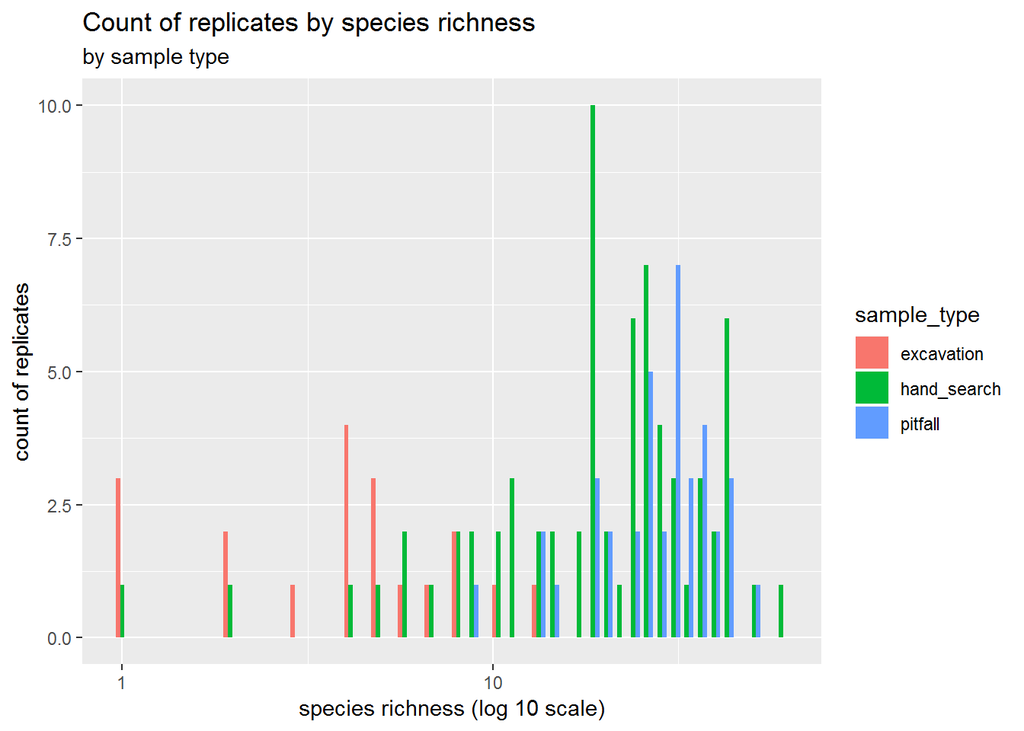

### Sampling effort data

Sampling effort data is available from a study of the reported methodologies for each survey and have been compiled for analysis. An extract of the data is shown below. `effort_P` represents the number of pitfall trap samples. Note it does not represent the number of actual traps, rather a set of traps (quantity given in `n_pitfall` if known), set out for a period of time, e.g. 2 weeks, counts as 1 ‘effort’. `effort_T` represents the number of timed samples, both a timed hand search and a timed excavation count as 1 ‘effort’. `effort_combined` is simply the sum of `effort_P` and `effort_T`. The other columns are not currently being used for analysis (and I’m afraid the time period columns have been mangled in transition from excel to R - its possible to fix that, but wasn’t a priority).

Reported effort

| event_code | author | effort_P | effort_T |
| --- | --- | --- | --- |
| Wye_2014_5 | Henshall et al | 0 | 2 |
| Lugg_2014_2 | Henshall et al | 2 | 3 |
| Lugg_2014_1 | Henshall et al | 4 | 4 |
| Lugg_2014_3 | Henshall et al | 4 | 4 |
| Lugg_2014_4 | Henshall et al | 4 | 4 |
| Wye_2014_4 | Henshall et al | 4 | 4 |
| Wye_2014_6 | Henshall et al | 4 | 4 |
| Wye_2014_7 | Henshall et al | 4 | 4 |
| Wye_2014_3 | Henshall et al | 4 | 5 |
| Breamish_2013 | Webb & Mott | 1 | 8 |
| Till_2013_lower | Webb & Mott | 1 | 8 |
| Till_2013_upper | Webb & Mott | 1 | 4 |
| Trent | Webb & Mott | 0 | 7 |
| Tweed_2013 | Webb & Mott | 0 | 4 |
| Wye_2014_1 | Webb & Mott | 1 | 8 |
| Dove_2013 | Webb & Mott | 2 | 4 |
| Wooler_2013 | Webb & Mott | 1 | 8 |
| Monnow_2015 | Webb & Mott | 1 | 4 |

The effort counts are in fact the same thing as the number of replicates of each sample type. Unfortunately, they don’t correspond well with the inferred replicates discussed above.

Here is the difference between the reported method and the replicates found in the data:

Reported effort subtracted from actual effort

| event_code | effort_P | effort_T |
| --- | --- | --- |
| Breamish_2013 | 0 | 0 |
| Dove_2013 | -1 | 4 |
| Lugg_2014_1 | 0 | 0 |
| Lugg_2014_2 | 0 | -1 |
| Lugg_2014_3 | 0 | 0 |
| Lugg_2014_4 | 0 | 0 |
| Monnow_2015 | 0 | 4 |
| Till_2013_lower | 0 | -4 |
| Till_2013_upper | -1 | 3 |
| Trent | 0 | -3 |
| Tweed_2013 | 1 | 4 |
| Wooler_2013 | 0 | -4 |
| Wye_2014_1 | 1 | -4 |
| Wye_2014_3 | 0 | 0 |
| Wye_2014_4 | 0 | 0 |
| Wye_2014_5 | 0 | 0 |
| Wye_2014_6 | 0 | 0 |
| Wye_2014_7 | 0 | 0 |

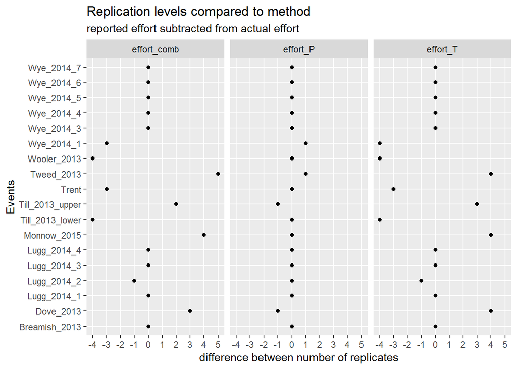

## Create frequency matrix

This matrix calculates the frequency each species occurs in each replicate.  
- because it’s by ‘replicate’ each species should only occur once, so in this case the frequency matrix is the same as an occurrence matrix.

|  | river | replicate | event_code | location | sample_type |
| --- | --- | --- | --- | --- | --- |
| 50 | Monnow | Monnow_2015-HS-1A | Monnow_2015 | 1A | hand_search |
| 95 | Wye | Wye_2014_3-HS-3D | Wye_2014_3 | 3D | hand_search |
| 81 | Wooler Water | Wooler_2013-HS-JRW1 | Wooler_2013 | JRW 1 | hand_search |
| 112 | Wye | Wye_2014_6-HS-6B | Wye_2014_6 | 6B | hand_search |
| 5 | Breamish | Breamish_2013-HS-JRW1 | Breamish_2013 | JRW 1 | hand_search |
| 60 | Till | Till_2013_lower-PF-Pitfalls | Till_2013_lower | Pitfalls | pitfall |
| 67 | Till | Till_2013_upper-HS-UpperTill1(NM4) | Till_2013_upper | Upper Till 1(NM 4) | hand_search |
| 123 | Wye | Wye_2014_7-PF-7A | Wye_2014_7 | 7A | pitfall |
| 7 | Breamish | Breamish_2013-HS-NM2 | Breamish_2013 | NM2 | hand_search |
| 13 | Dove | Dove_2013-EX-dig4 | Dove_2013 | dig 4 | excavation |

## Species accumulation curves

In this section I’ll start looking at species accumulation curves, with an emphasis on methodological differences. Initially I’ll be comparing different ways of subdividing the data (mainly by sample type and/or replicate).

The following events have been selected for analysis: Wye_2014_6, Lugg_2014_3, Lugg_2014_1, Lugg_2014_2, Lugg_2014_4, Wye_2014_3, Wye_2014_7, Wye_2014_4, Wye_2014_5, Breamish_2013, Monnow_2015, Till_2013_lower, Trent, Tweed_2013, Wye_2014_1, Dove_2013, Till_2013_upper, Wooler_2013

### Grand total accumulation

This doesn’t really tell us a lot, except that combining all sampling methods and all surveys doesn’t reach an asymptote. Because this covers a number of rivers and surveys, I’m not sure we need to read much into this.

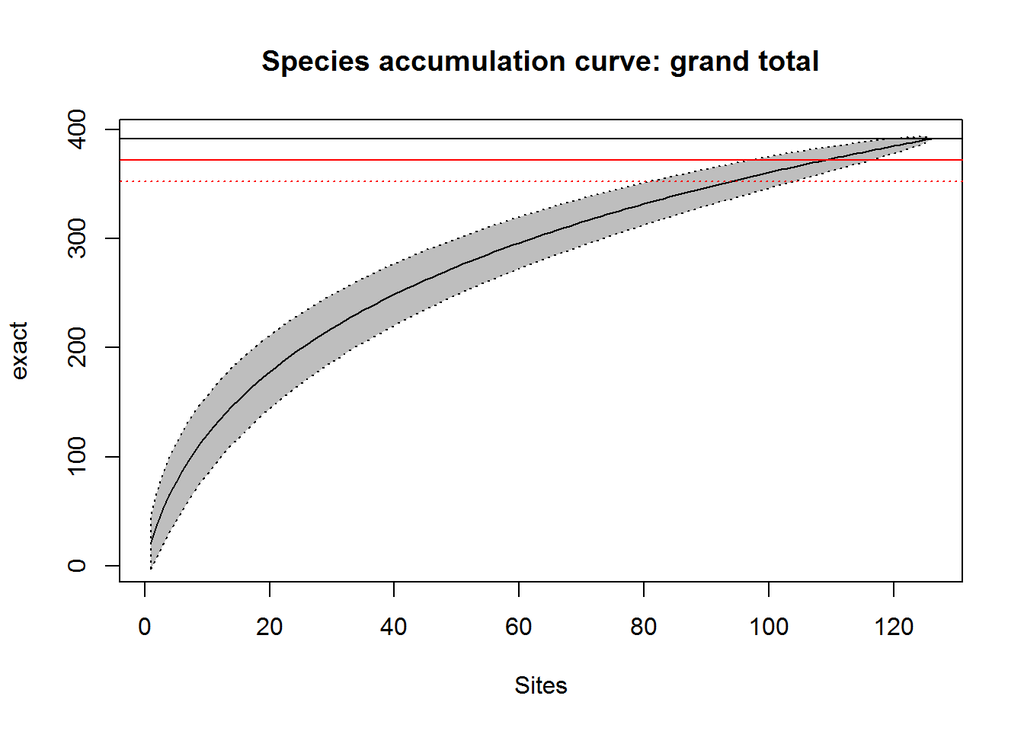

### Sample type accumulation

Here we’ll look at species accumulation curves by sample type.

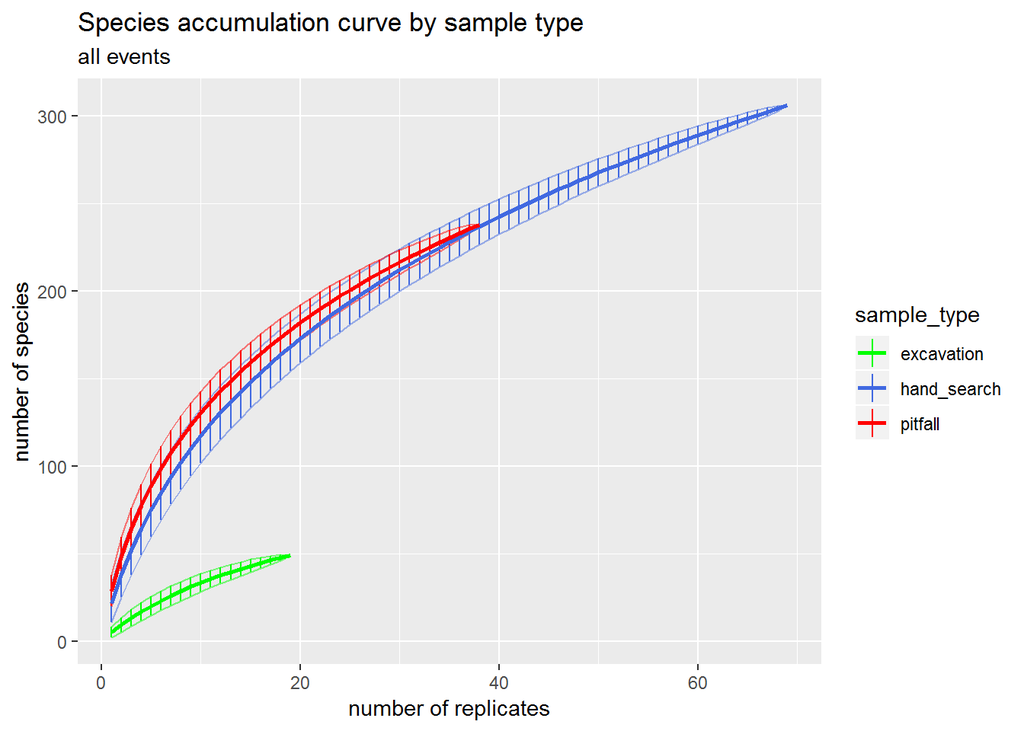

### Accumulation by event

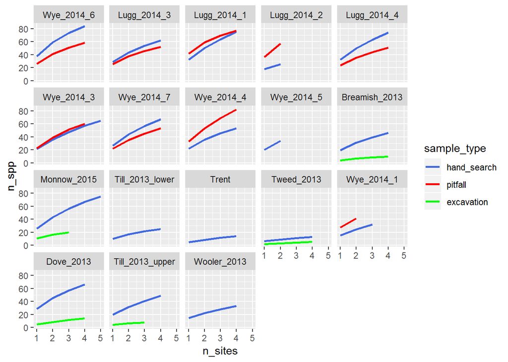

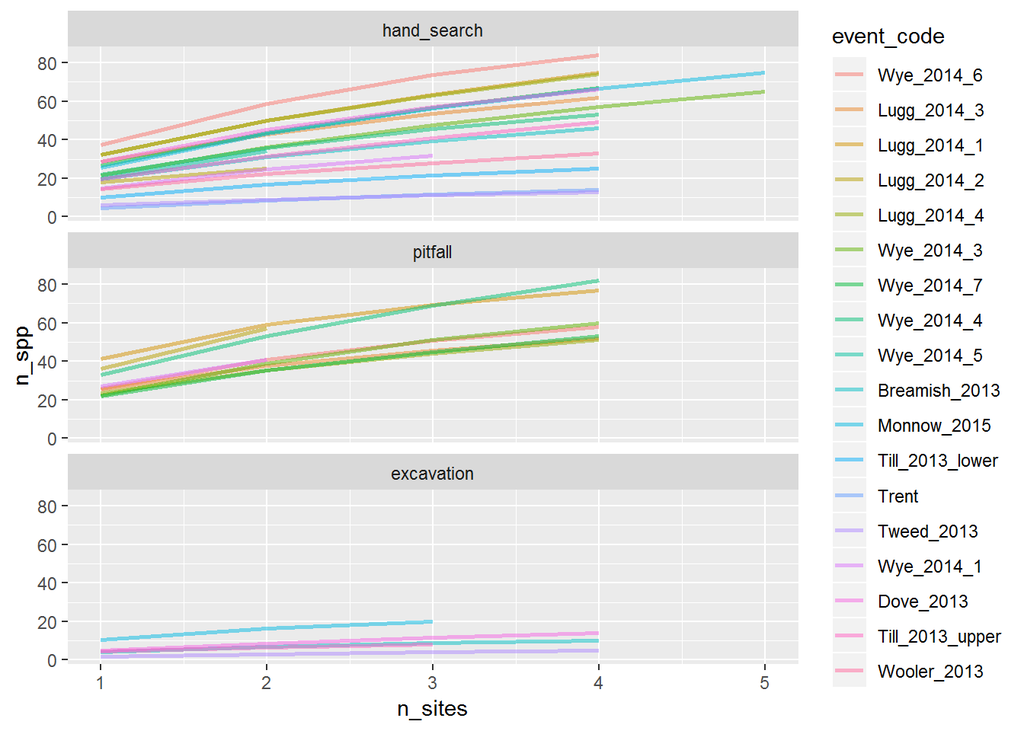

### Accumulation combining pitfall and handsearch

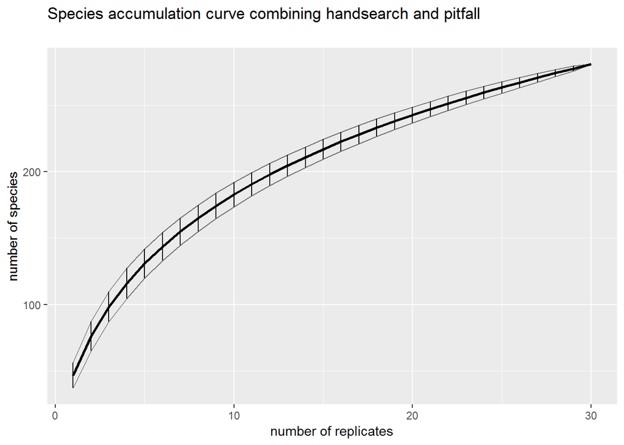

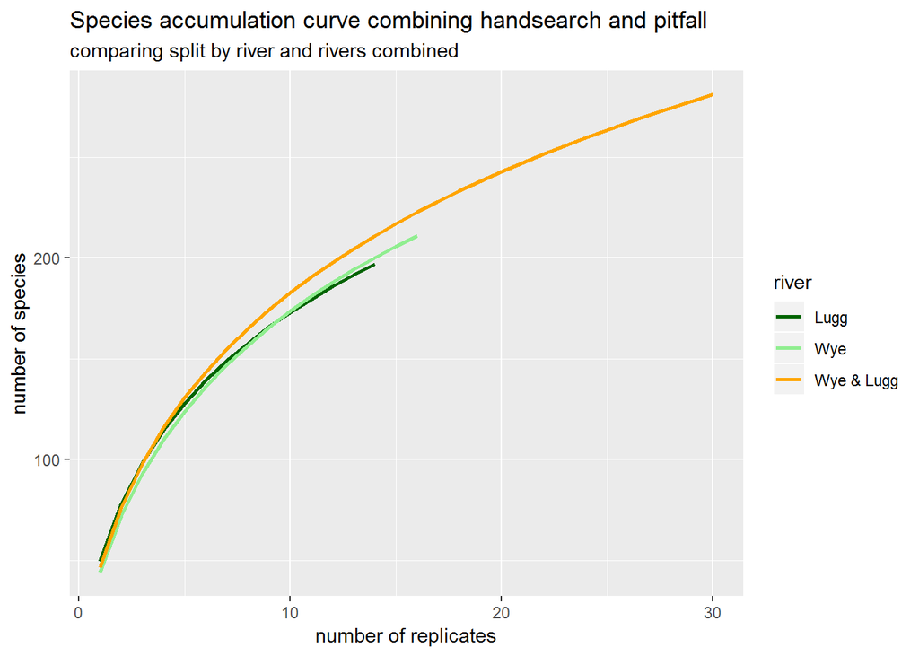

### All together

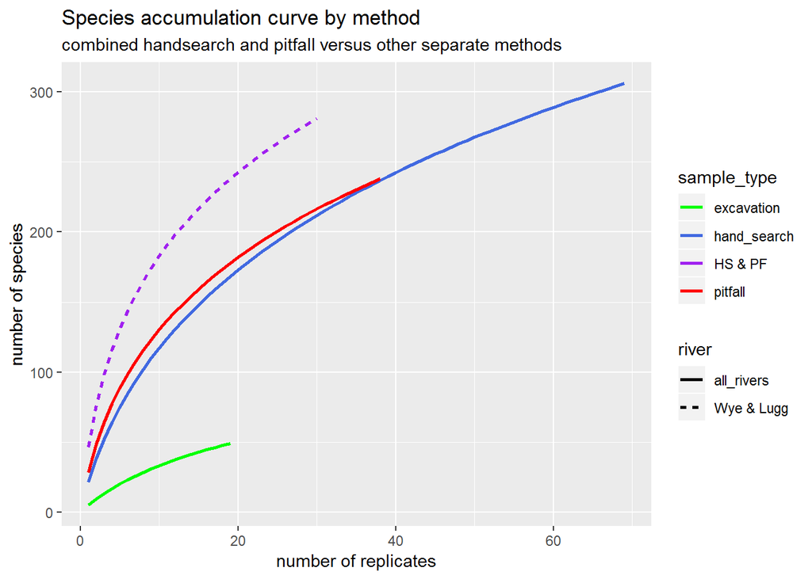